# Long-term heat (LTH): key results

Heat and wound repair in *Acropora pulchra*, Mo’orea 2025

Updated 2026-09-22

**What we found:** At 31 °C, coral fragments became paler, lost algae from their tissue, and gained less skeletal mass. Wounds still sealed, but only 4 of 12 heated fragments budded new corallites, the small skeletal cups on a regrown tip, by Day 15. All 12 fragments at 28 °C did so. Fragments from source patch C were less affected by heat than those from A and D.  
**Still preliminary:** The DNA-marker results do not yet confirm which fragments are genetically identical. A, C, and D therefore remain names for the field patches where we collected the parent material.  
**Species name:** Species identification remains provisional: *Acropora cf. pulchra*. The abbreviation *cf.* means “compare with” and indicates that the species identification is uncertain. We retain *A. pulchra* here to match the project’s existing labels.

We kept coral fragments at 28 °C or 31 °C and clipped the growing tip on half of them. Over 15 days, we measured wound repair, skeletal growth, color, photosynthesis efficiency, and the algae living in coral tissue, called **algal symbionts**.

## The experiment

- 8 tanks: four held at 28 °C, four at 31 °C
- Half the fragments had the growing tip clipped; half were left unwounded
- 3 field source patches: A, C, D. A source patch is where the parent material came from; these patches are not yet confirmed genetic individuals.
- Tissue samples collected on Days 1, 3, 10, and 15
- The 48 fragments sampled on Day 15 were also followed for coral condition and regrowth; 24 were wounded
- A separate experiment followed wound covering in 16 wounded fragments using microscope photos

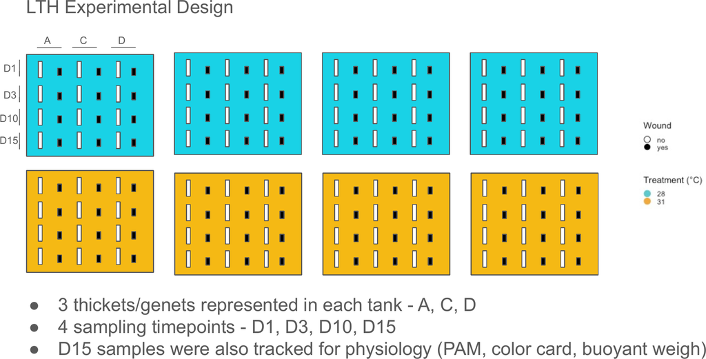

The experiment used eight tanks: four at 28 °C and four at 31 °C. Each tank held coral fragments from three source patches, meaning the field patches where the parent material came from: A, C, and D. Some fragments were clipped at the growing tip and others were left unwounded. Fragments were sampled on Days 1, 3, 10, and 15. Day 15 fragments were also measured for photosynthesis score, color, and skeletal mass.

We wounded each clipped fragment by removing the growing tip. The Day 0 photo below shows the fresh cut surface.

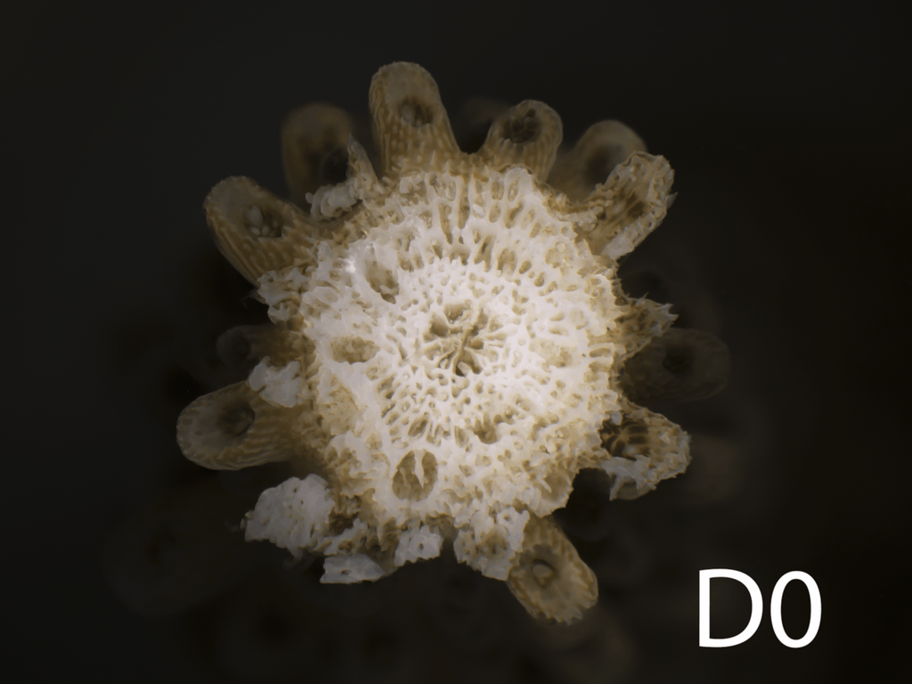

Tip clipping created the wound. This Day 0 photo shows a heated *Acropora pulchra* fragment immediately after clipping. The pale center is the fresh cut surface. The surrounding corallites, the small skeletal cups, are still intact.

## What we found

### 1. The +3 °C temperature difference held

All eight tanks have 144 readings per day, one every ten minutes, from Day 0 through Day 15 (4–19 June 2025). Daily tank means averaged **27.78 °C** in the 28 °C treatment and **30.87 °C** in the 31 °C treatment, a **3.09 °C difference**. Each treatment had four tanks.

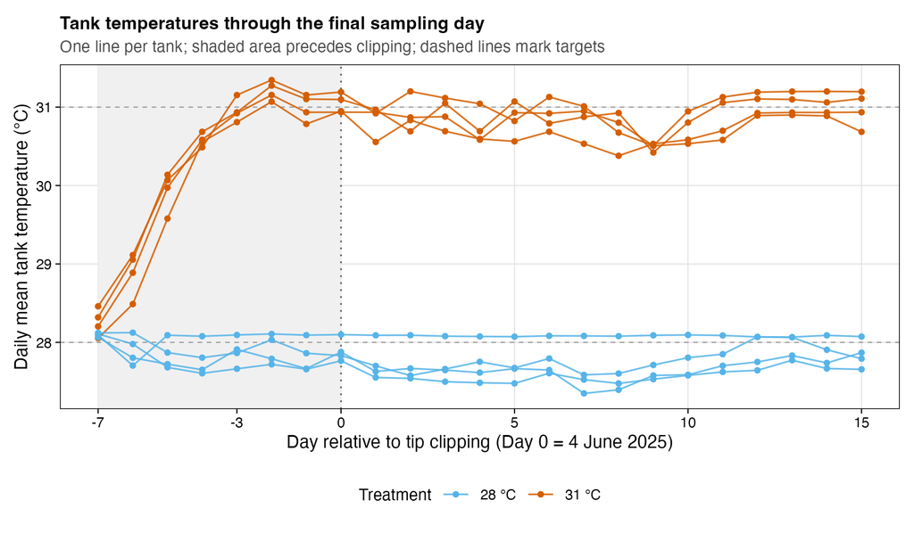

The intended temperature difference held through the final sampling day. Points are daily means of 144 readings per tank at ten-minute intervals. Each line follows one tank: blue = 28 °C and orange = 31 °C, four tanks per treatment. The x-axis runs from 28 May to 19 June 2025, relative to clipping on 4 June (Day 0). Gray shading marks the period before clipping; dashed horizontal lines mark the targets. All eight tanks have a complete daily record for Days 0–15. Dates follow the displayed logger clock. These are measured temperatures, not model fits; no uncertainty bands are shown.

The temperature record is complete through Day 15. Treatment averages exclude later days, after the main experiment ended.

### 2. Heat reduced coral condition and growth

At 31 °C, fragments became paler, gained less skeletal mass, and lost algal symbionts. Their photosynthesis-efficiency score, **Fv/Fm**, also fell. This score measures how efficiently the algae’s photosynthetic system can use light.

These changes were similar in clipped and unwounded fragments. We found little evidence that tip clipping added to the decline caused by heat.

- Photosynthesis score and color declined through time under heat.
- Symbiont density dropped sharply over the two weeks.
- Skeletal mass gain was **34% lower** at 31 °C. Because temperature was assigned to tanks, the test uses four tanks per treatment as the independent replicates. The growth difference remains uncertain (*p* = 0.057).

**Photosynthesis and color through time**

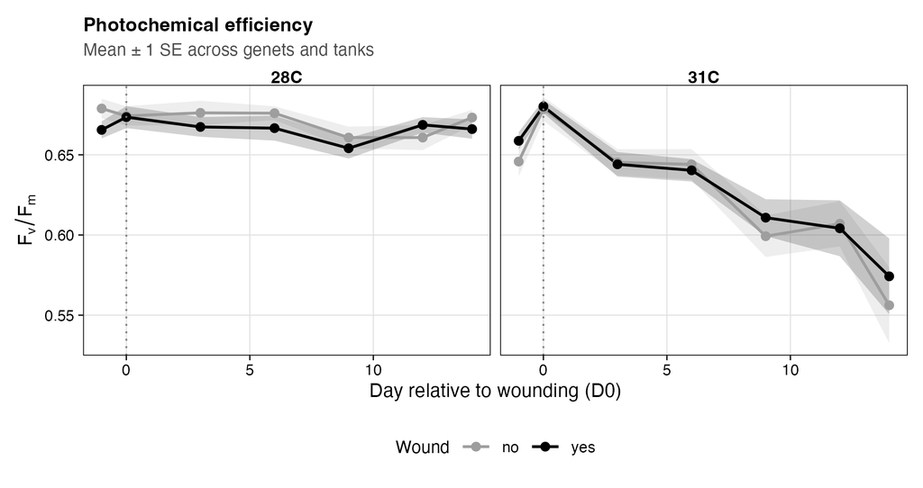

Photosynthesis efficiency declined under heat. Panels separate the two temperatures; lines distinguish wounded and unwounded fragments (yes/no in the legend). Points are observed fragment means, with measurement locations averaged within fragments. Shaded bands show one standard error on either side of each group mean, not tank-adjusted confidence intervals. Day 0 marks clipping. Source patches are combined.

**Near the tip versus near the base.** We measured photosynthesis efficiency about 1 cm from each end of every fragment. All 48 fragments have both readings at all seven visits. Both locations declined under heat, so the overall heat response does not depend on averaging them.

From Day 0 onward, the tip score averaged 0.012 below the base at 28 °C and 0.021 below it at 31 °C. The estimated extra tip-to-base difference under heat was small and uncertain: −0.009 score units (95% interval −0.023 to 0.006; tank-level test, *p* = 0.20). The gap varied through time, but the tank-level comparison did not clearly show different time patterns between temperatures (*p* = 0.143). We also found no clear added effect of clipping on the gap.

The two-location average remains useful for describing overall fragment condition. It does **not** mean the locations are equivalent or that a local response near the wound is absent. We retain both readings for the location comparison.

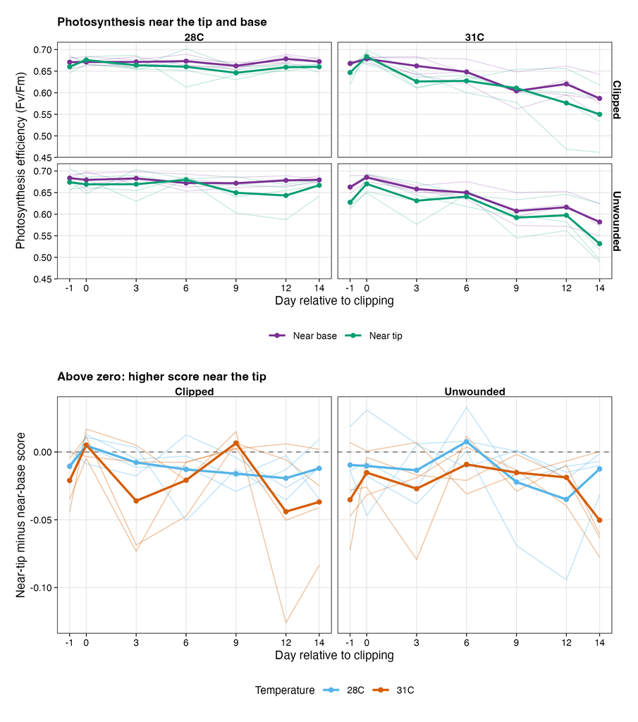

Both sampled locations lost photosynthesis efficiency under heat. Upper panels show readings about 1 cm from the tip (green) and base (purple), separately for clipped and unwounded fragments. Thin lines are observed tank means; thick lines average the four tanks per temperature. Lower panels show the paired difference, near-tip minus near-base, calculated within each fragment before averaging by tank. Negative values mean lower efficiency near the tip. Each tank contributes three fragments per wound state. Day −1 is before clipping, not an unheated baseline; statistical comparisons use Days 0–14. Lines describe observations, not model fits or uncertainty bands.

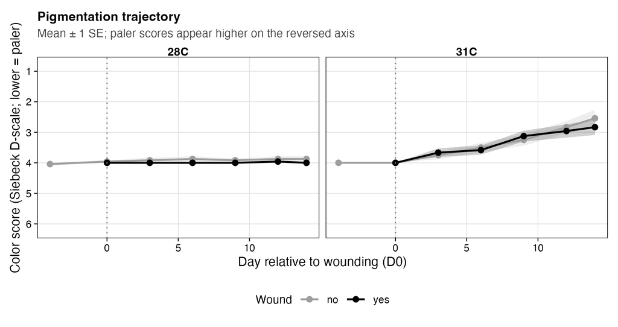

Heated fragments became paler. Panels separate temperatures and lines distinguish wounded and unwounded fragments (yes/no). Lower color scores mean paler tissue; the axis is reversed, so lower scores appear higher on this plot. Points are observed means across fragments and shaded bands show one standard error on either side, not tank-adjusted confidence intervals. Day 0 marks clipping. Source patches are combined.

**Skeletal growth and algal symbionts**

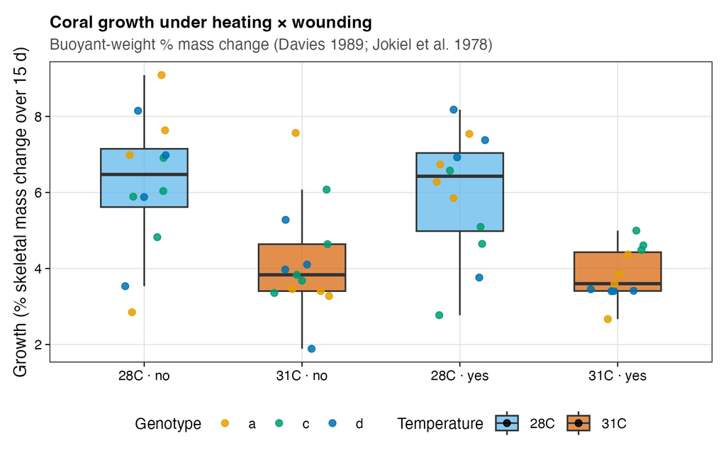

Heated corals gained less skeletal mass. The y-axis is percent mass change over 15 days. Each dot is one fragment. Boxes show the middle half of the fragments and the median. Dot colors mark source patch, not confirmed genetic individual: gold = A, green = C, blue = D. Box colors mark temperature: blue = 28 °C and orange = 31 °C. Sample sizes are 12, 13, 12, and 11 fragments for 28 °C-unwounded, 31 °C-unwounded, 28 °C-wounded, and 31 °C-wounded.

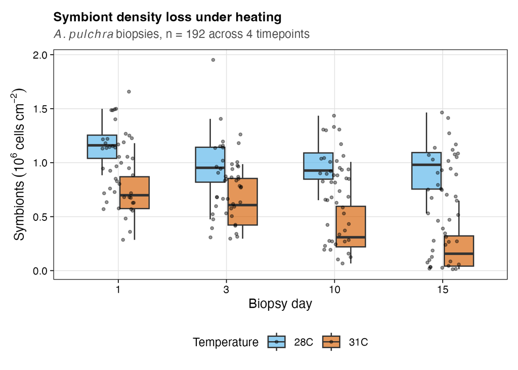

Heated corals lost algal symbionts, the algae living in coral tissue, over time. The y-axis is millions of symbiont cells per square centimeter. Each gray dot is one small tissue sample. Boxes show the middle half of the tissue samples and the median. Blue boxes show 28 °C and orange boxes show 31 °C. Wounded and unwounded fragments are combined here. Sample size = 24 tissue samples per temperature and day, 192 total.

### 3. Wounds sealed, but fewer heated fragments completed regrowth

Wounds re-covered with living tissue quickly at both temperatures. Only **4 of 12 heated fragments (33%)** had budded new corallites, the small skeletal cups on the rebuilt tip, by Day 15. All **12 of 12 fragments at 28 °C (100%)** had done so. A longer experiment might have allowed more heated fragments to reach this step; these data cannot tell us whether the delay was permanent.

Here, **healing** means the coenosarc, the sheet of living tissue between coral polyps, re-covered the wound. **Regeneration** means the later rebuilding steps: the main polyp forms, the wound surface remodels, the tip returns, the tip extends, and new corallites bud.

The healing panel uses a separate microscope-photo experiment with 16 wounded fragments, eight per temperature. The other panels use the 24 wounded fragments in the main experiment, 12 per temperature. All 14 fragments scored for tissue cover on Day 1 were covered. Two heated fragments lacked that day’s score; all 16 were recorded as covered by Day 2. The microscope photos illustrate the stages in a separate group; they cannot verify individual scores in the main experiment.

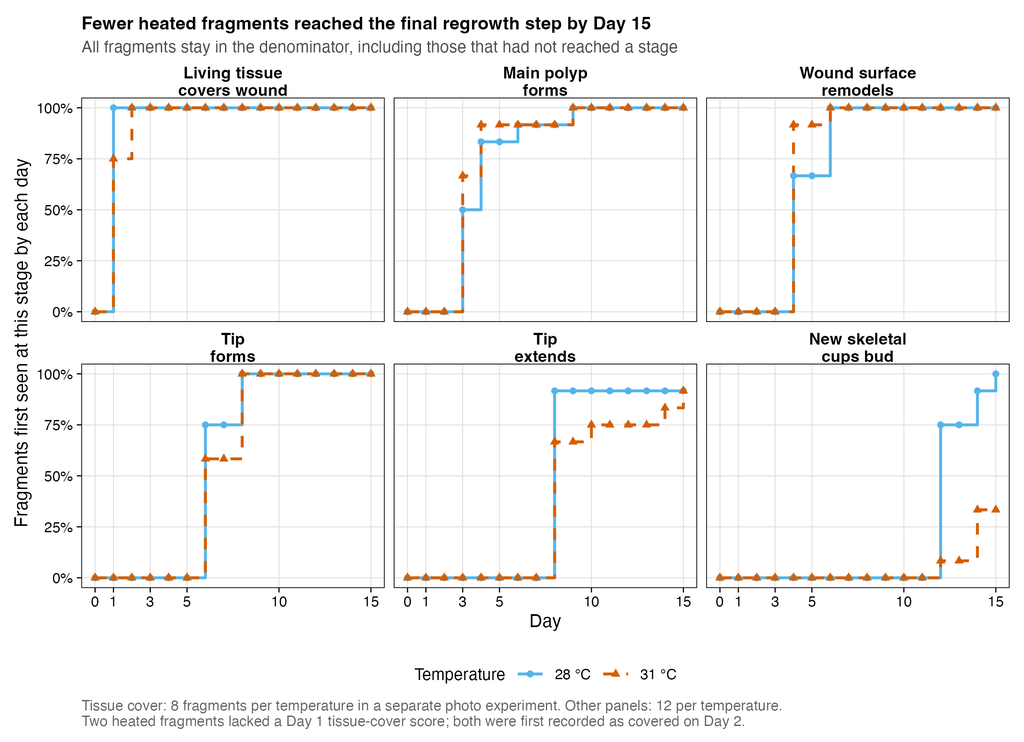

Heat reduced the percentage reaching the final regrowth step by Day 15. Each panel shows the percentage first observed at a stage by each day after clipping. Blue solid lines and circles = 28 °C; orange dashed lines and triangles = 31 °C. Each percentage uses all fragments in that panel, including those that had not reached the stage. Living tissue covering the wound uses a separate microscope-photo experiment, with 8 wounded fragments per temperature. The other five panels use 12 wounded fragments per temperature from the main experiment. Two heated fragments lacked a Day 1 tissue-cover score; both were first recorded as covered on Day 2. That small difference in first observations does not establish slower healing. New skeletal cups are new radial corallites on the regrown tip. Curves show observed attainment, not fitted probabilities or continued presence of a feature. No uncertainty bands are shown, and the curves do not predict what happened after Day 15.

The curves show the percentage first recorded at each stage by each day. Each percentage includes all fragments, including those that had not reached the stage. Once a fragment has a positive score, it remains counted, even if a later score marks the feature absent. A later absence may reflect a real change or a scoring inconsistency; these curves do not distinguish the two.

Fragments observed at each stage at least once by Day 15. Tissue cover uses the separate microscope-photo experiment; other rows use the main experiment.

| Stage | 28 °C | 31 °C |
| --- | --- | --- |
| Living tissue covers wound | 8/8 (100%) | 8/8 (100%) |
| Main polyp forms | 12/12 (100%) | 12/12 (100%) |
| Wound surface remodels | 12/12 (100%) | 12/12 (100%) |
| Tip forms | 12/12 (100%) | 12/12 (100%) |
| Tip extends | 11/12 (92%) | 11/12 (92%) |
| New skeletal cups bud | 12/12 (100%) | 4/12 (33%) |

This differs from asking whether a feature was **present on Day 15 itself**. For example, every fragment had formed a tip at some point, but a tip was visible on 11 of 12 fragments in each treatment on Day 15. Tip extension had been recorded on 11 of 12 in each treatment, although it was visible on only 9 of 12 heated fragments on Day 15. The table and curves consistently show “reached by,” not “present on.”

**Average time to each stage.** Each point averages the first observation days of fragments that reached that stage. Filled points include every fragment; open points leave out those that had not reached the stage by Day 15. The counts show how many contribute. We keep the percentage-by-day plot above as the main comparison because it includes all fragments.

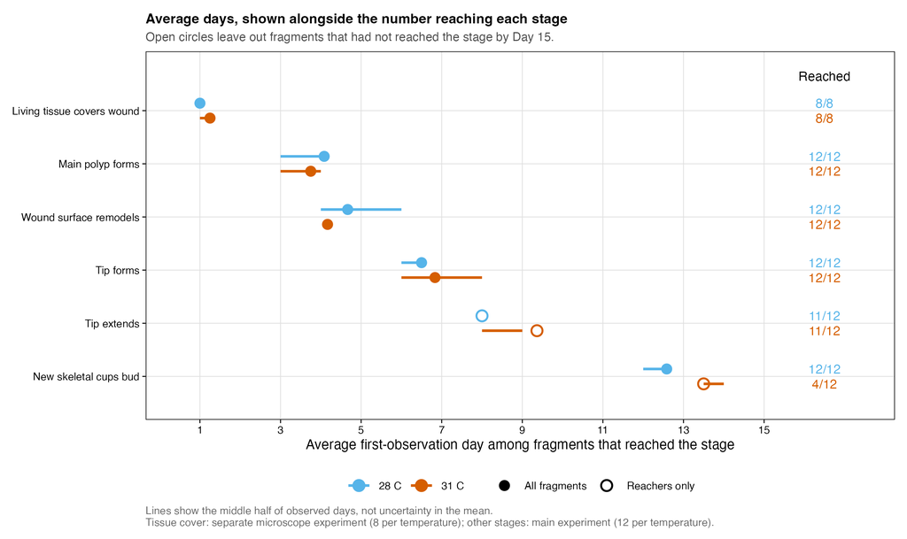

Average first-observation days among fragments that reached each stage. Blue = 28 °C; orange = 31 °C. Points show means; horizontal lines show the middle half of observed first days, not confidence intervals. Open points average only fragments that reached the stage by Day 15. Right-hand labels give reached/total counts. Tissue cover uses 8 fragments per temperature from the separate microscope experiment; other stages use 12 per temperature from the main experiment. In particular, the final heated-stage mean describes only 4 of 12 fragments and cannot represent the full heated group.

For incomplete stages, these averages favor the fragments that finished sooner. They do not estimate when the others would finish. The table below therefore keeps averages only for stages reached by every fragment at both temperatures.

Timing summaries for stages reached by all fragments at both temperatures. The middle-half range runs from the 25th to the 75th percentile. These are first observation days, not exact biological onset times. Two missing Day 1 tissue-cover scores affect the heated group’s observed mean.

| Stage | Temperature | Mean first-observation day | Middle half of first days |
| --- | --- | --- | --- |
| Living tissue covers wound | 28 °C | 1.00 | 1.00-1.00 |
| Living tissue covers wound | 31 °C | 1.25 | 1.00-1.25 |
| Main polyp forms | 28 °C | 4.08 | 3.00-4.00 |
| Main polyp forms | 31 °C | 3.75 | 3.00-4.00 |
| Wound surface remodels | 28 °C | 4.67 | 4.00-6.00 |
| Wound surface remodels | 31 °C | 4.17 | 4.00-4.00 |
| Tip forms | 28 °C | 6.50 | 6.00-6.50 |
| Tip forms | 31 °C | 6.83 | 6.00-8.00 |

**Individual timing and unfinished stages.** The distributions below show when fragments reached each stage, with unfinished stages retained above the day axis.

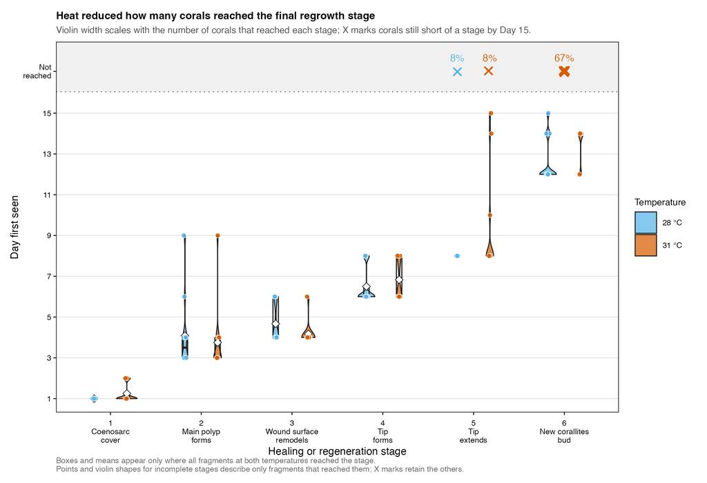

Heat reduced how many corals reached the final regrowth stage. The x-axis shows the healing and regeneration stages. The y-axis shows the first day a stage was seen. The gray top band shows fragments that had not reached a stage by Day 15. The shaded shapes summarize the first-day distribution among corals that reached a stage. Width reflects both how closely their first days cluster and how many corals reached the stage. Points are individual corals. X marks show individual fragments that had not reached a stage by Day 15. Percent labels in the gray band show the percentage not reached. Black box lines show the median and the middle half of first days. Boxes and white mean-day diamonds appear only for stages reached by every fragment at both temperatures. Blue = 28 °C and orange = 31 °C. Stage 1 uses the microscope-photo data set because coenosarc cover was scored there (8 wounded fragments per temperature). Stages 2-6 use the main morphology data set (12 wounded fragments per temperature). Shapes for incomplete stages describe only the fragments that reached them. The key pattern is that all 12 wounded 28 °C fragments budded new radial corallites by Day 15, while only 4 of 12 wounded 31 °C fragments did.

**Exact observation days for each fragment**

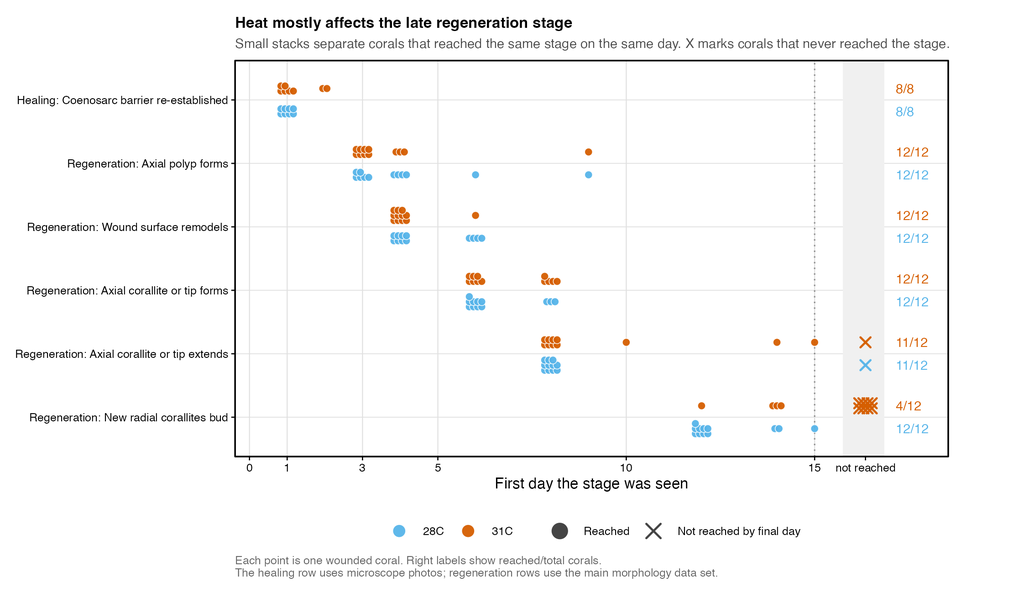

This exact-day plot separates early healing from later regeneration. Healing means the coenosarc, the sheet of living tissue between coral polyps, re-covered the wound surface. Regeneration means the later rebuilding steps. Each point is one wounded coral. The x-axis shows the first day a stage was seen. Small stacks separate corals that reached the same stage on the same day. An X in the gray band means the coral never reached that stage by the final scored day. The early healing row uses the microscope-photo data set because coenosarc cover was scored there. The regeneration rows use the main morphology data set. Right-side labels show how many corals reached each stage out of the number scored. The main pattern is that both temperatures reached early healing and most early rebuilding steps, but only 4 of 12 heated corals budded new radial corallites by Day 15 compared with 12 of 12 at 28 °C.

**Scoring uncertainty.** Three fragments have a tip scored present and later absent: in two, it remains marked absent through the end; in the third, it is absent for one day. Another fragment has budding recorded one day before tip extension. These observations need review, not automatic correction. Pigment scores are also missing for 23 of 24 wounded fragments on Day 9; missing scores remain unknown, not absent. Pigment is not one of the six stages plotted above.

The earlier check that omitted fragments 121 and 115 still gives 11/11 fragments at 28 °C versus 3/11 at 31 °C reaching new-corallite budding. That check addresses those two records only, not every scoring uncertainty. Original scores and models are unchanged pending review.

**How the timing models handle unfinished stages.** A fragment that had not reached a stage by its final observation contributes “not yet reached” information. It is not dropped or assigned an invented completion day. For fragments that did reach a stage, the main timing model places onset between the last absent score and the first present score.

The existing model estimates a **1.32-fold longer time** to new-corallite budding at 31 °C. This is a model estimate, not the average time of the four heated fragments that budded. It assumes a particular pattern of event times and adjusts for source patch; its uncertainty does not account for fragments sharing a tank. The observed 4/12 versus 12/12 result does not depend on that model.

A closed wound is not the same thing as a regenerated tip. If we scored only wound sealing, we would miss the main heat effect.

The two fragments shown below both seal the wound and rebuild a tip. Only the fragment at 28 °C buds new corallites by Day 15.

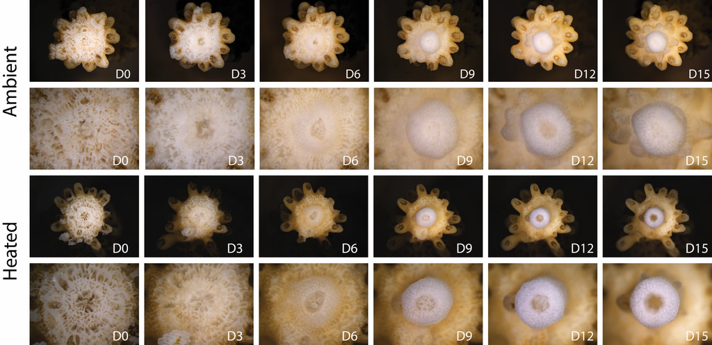

The photos show wound sealing and later regrowth as separate steps. Columns are days after clipping, from Day 0 to Day 15. Rows show 28 °C and 31 °C fragments at whole-tip and close-up views. Both fragments seal the wound and rebuild a tip. Only the 28 °C fragment buds new corallites by Day 15.

The time-lapse follows these two fragments from Day 0 to Day 15: 28 °C on the left and 31 °C on the right.

[video not shown]

28 °C time-lapse: the wound seals, the tip rebuilds, and new corallites bud by Day 15.

[video not shown]

31 °C time-lapse: the wound seals and the tip rebuilds, but new corallites have not budded by Day 15.

### 4. Source patch C was hurt less by heat

Fragments from **source patch C** retained more of their photosynthesis efficiency, color, and algal symbionts under heat than fragments from A and D. Growth followed the same pattern, but the evidence for a growth difference is weaker.

We compare each patch at 31 °C with the same patch at 28 °C. That tells us how much heat changed its response, rather than which patch had the highest starting value.

The figures below summarize these differences as a **heat penalty**: how much worse a response was at 31 °C than at 28 °C. Each measurement is put on a relative scale before the penalties are averaged.

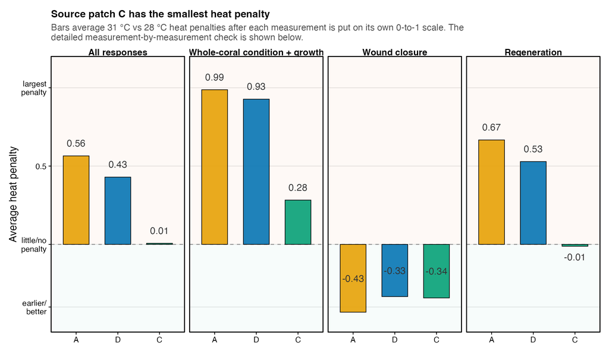

Source patch C had the smallest heat penalty. A heat penalty means how much worse 31 °C was than 28 °C. Bars show the average heat penalty for source patches A, C, and D. Separate bars show all measurements together, coral condition and growth, wound sealing, and regrowth timing. Each measurement was first put on its own relative scale, so the bars compare source-patch heat penalties, not raw measurements collected on different days. Values near zero mean little heat penalty. Positive values mean worse condition or slower regrowth at 31 °C. Negative values mean better condition or faster regrowth at 31 °C. A, C, and D are source-patch labels, not confirmed genetic individuals.

In the summary plot, source patch C stays near zero overall. Source patches A and D have bigger condition, growth, and regrowth penalties. Wound-sealing traits sit near or below zero because heat did not slow sealing itself.

The four condition and growth measurements each show a smaller estimated heat penalty for C.

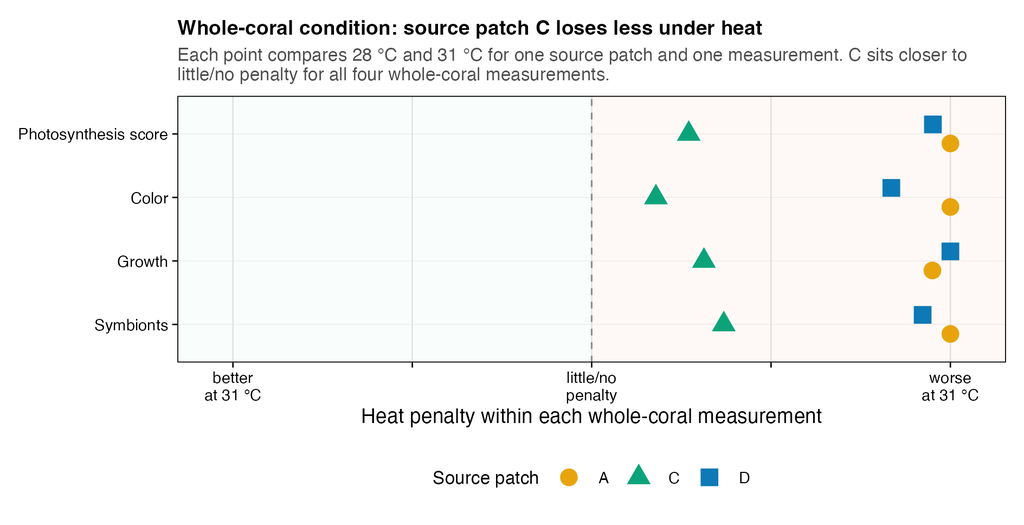

Source patch C had the smallest heat penalties for coral condition and growth. A, C, and D are source-patch labels, not confirmed genetic individuals. Each point is one measurement: photosynthesis score, color, symbiont density, meaning algal cells per coral area, or skeletal growth. For each measurement, the largest absolute heat penalty among source patches is set to 1 so the measurements can be compared on the same relative scale. Photosynthesis score and color use Day 14 values, symbionts use the final tissue sample, and growth uses the full 15-day change. Wounded and unwounded fragments are averaged together. Points near zero mean little heat penalty; points to the right mean worse condition or growth at 31 °C.

The next plot shows the measurements used in the combined score.

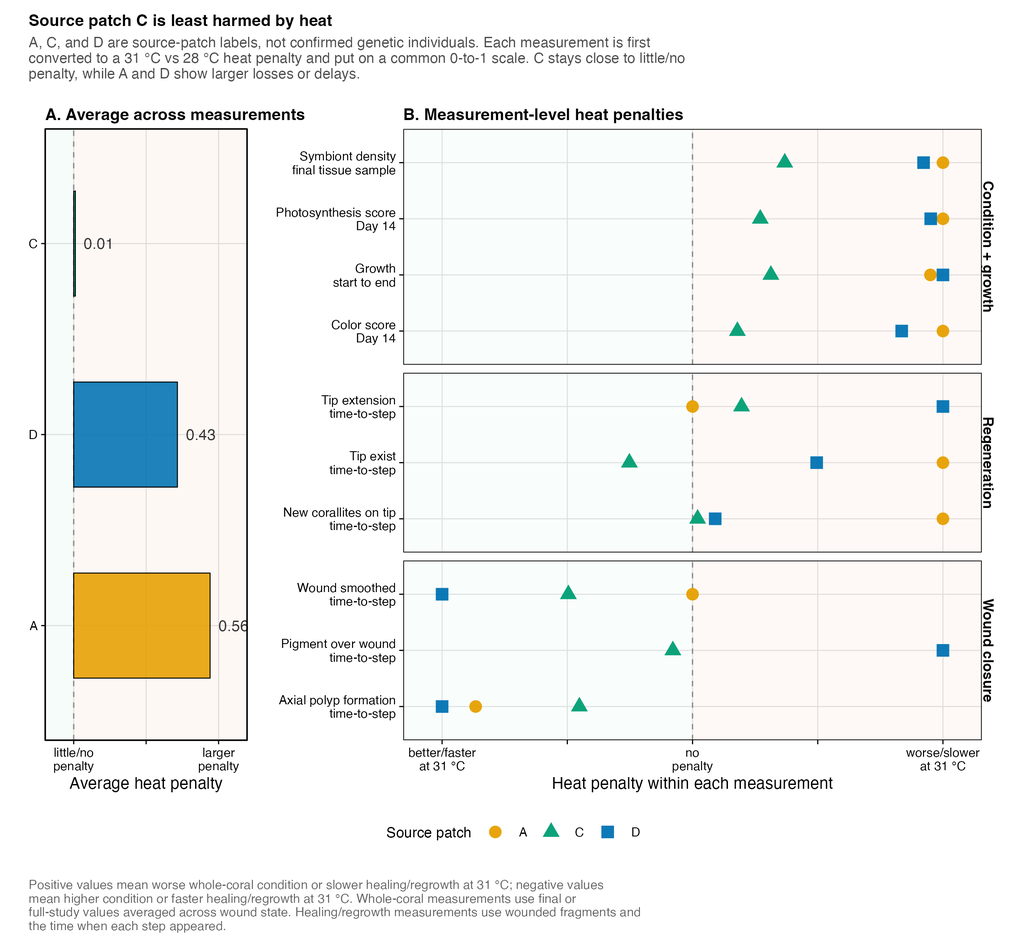

Source patch C stayed near zero across most heat-penalty measurements. A, C, and D are source-patch labels, not confirmed genetic individuals. (a) Mean heat penalty across all measurements that could be estimated for each source patch. (b) Heat penalties for each measurement, grouped by measurement type. Each point is one source-patch heat penalty for one measurement. Each measurement was put on its own relative scale, with the largest absolute effect set to 1. These are not raw measurements from the same day. Coral-condition rows use late-study values: photosynthesis score and color at Day 14, growth over the full study, and symbionts from the final tissue sample. Healing/regrowth rows use timing analyses for wounded fragments only. Points left of zero mean better condition or earlier regrowth at 31 °C. Points right of zero mean worse condition or slower regrowth at 31 °C. Gold circles = A, green triangles = C, blue squares = D. The averages include 9 measurements for A and 10 each for C and D; some timing effects could not be estimated.

The final plot focuses on wound repair and regrowth.

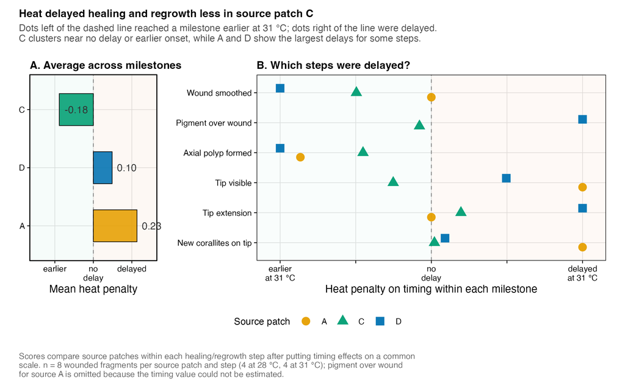

Source patch C had smaller estimated heat penalties for repair timing. A, C, and D are source-patch labels, not confirmed genetic individuals. (a) Average heat penalty for the timing of wound sealing and regrowth for each source patch. (b) Heat penalties for each healing or regrowth step. Values come from timing analyses for wounded fragments only. Within each step, the largest effect in either direction is scaled to a size of 1, keeping its sign. Points left of the dashed zero line mean the step happened earlier at 31 °C. Points right of zero mean it happened later at 31 °C. Gold circles = A, green triangles = C, blue squares = D. Sample size = 8 wounded fragments per source patch and step, with 4 at 28 °C and 4 at 31 °C. Heat-penalty values averaged: A = 5, C = 6, D = 6. Pigment over wound for source patch A is omitted because the timing analysis could not estimate that effect.

**How the heat-penalty score is built**

The score has two steps.

**Step 1: calculate the heat effect for each source patch within each measurement.**

For whole-fragment condition and growth:

$$\text{heat effect}_{source,measurement} =
\text{estimated value at }28^\circ\text{C} - \text{estimated value at
}31^\circ\text{C}$$

For these measurements, higher values mean better coral condition or growth. A positive heat effect means the source patch did worse at 31 °C.

For repair timing, the model compares how quickly fragments reach a step while they have yet to reach it. This comparison is called a **hazard ratio (HR)**: the rate at 31 °C divided by the rate at 28 °C.

$$\text{heat effect}_{source,measurement} =
-\log(\text{HR}_{31^\circ\text{C} / 28^\circ\text{C}})$$

If HR is below 1, the step occurred more slowly at 31 °C. Taking its natural logarithm and reversing the sign gives a positive heat penalty.

**Step 2: put each measurement on the same scale, then average.**

$$\text{scaled heat penalty}_{source,measurement} =
\frac{\text{heat effect}_{source,measurement}}
{\max(|\text{heat effect}_{A,measurement}|,\ |\text{heat
effect}_{C,measurement}|,\ |\text{heat effect}_{D,measurement}|)}$$

This makes the largest source-patch difference within each measurement equal to 1 in size. It keeps the sign: positive means worse or slower at 31 °C; negative means better or faster at 31 °C.

$$\text{source heat-penalty score}_{source} =
\text{mean of scaled heat penalties across usable measurements}$$

We compare temperatures within each measurement before combining the effects. Photosynthesis score and color use Day 14, symbionts use the final tissue sample, and growth uses the full 15-day change. Those comparisons average wounded and unwounded fragments. Repair timing uses wounded fragments only.

The combined scores are **C = 0.01, A = 0.56, and D = 0.43**. They summarize relative responses, not a formal test of differences among patches. The averages include nine effects for A and ten each for C and D because some timing effects could not be estimated. The patches therefore do not contribute exactly the same measurements.

**Possible trade-offs**

A trade-off would mean that better performance in one response comes with worse performance in another. Source patch C grew less at 28 °C but lost less growth under heat. The pattern remains when growth is left out of the heat-penalty score. Still, this comparison has only three source patches. A plot of growth against growth lost under heat also uses the 28 °C growth value on both axes, so it cannot establish a trade-off on its own.

We found **no clear growth cost of regeneration** in the 12 heated wounded fragments. Fragments that budded new corallites gained 0.57 percentage points more mass, on average, than those that did not. That difference was uncertain (*p* = 0.196).

Models that followed when each fragment reached a stage also found no clear evidence that faster growth went with slower repair. Checks that reduced the influence of unusual observations, or omitted one fragment at a time, did not change that conclusion.

Some growth estimates were sensitive to individual fragments. With only 12 heated wounded fragments, we cannot rule out a smaller cost. These results show no clear trade-off so far; they do not show that regeneration is cost-free.

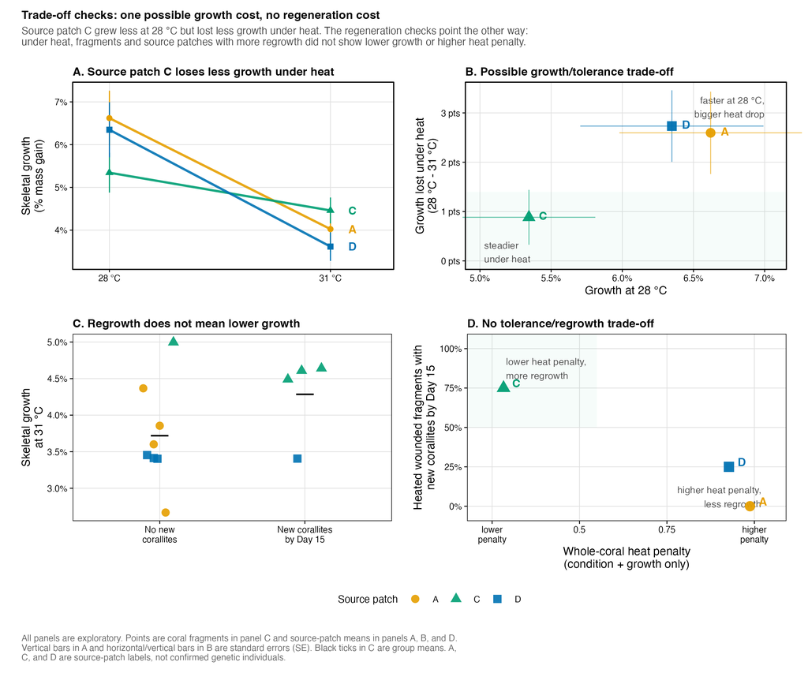

These plots suggest a possible growth–heat tolerance trade-off, but do not establish one. (a) Skeletal growth at 28 °C and 31 °C for each source patch. (b) Growth at 28 °C versus growth lost under heat, calculated as the 28 °C mean minus the 31 °C mean. (c) Skeletal growth of heated wounded fragments, grouped by whether they budded new corallites by Day 15. New corallites are the small skeletal cups on the regrown tip. (d) Whole-fragment heat penalty, based only on photosynthesis score, color, skeletal growth, and symbiont density, versus the percent of heated wounded fragments that budded new corallites by Day 15. Points are source-patch means in panels a, b, and d, and individual coral fragments in panel c. Vertical bars in panel a and horizontal and vertical bars in panel b are standard errors (SE). Black ticks in panel c are group means. Gold circles = A, green triangles = C, blue squares = D. Panel c uses 12 heated wounded fragments; panels a, b, and d use source-patch means. A, C, and D are source-patch labels, not confirmed genetic individuals. Panel b uses growth at 28 °C on both axes, so that relationship alone is not evidence of a trade-off. Panel c shows no clear growth cost of regrowth, but its small sample cannot rule out a cost. The text describes the model checks.

### 5. What the preliminary DNA markers and Hauru table change

Preliminary DNA-marker results group fragments by genetic similarity. The markers are **single-nucleotide polymorphisms (SNPs)**, differences at individual DNA positions. They came from **RNA sequencing (RNA-seq)**, which measures gene activity and can also reveal some DNA differences.

A group of genetically similar samples is called a **cluster**. These preliminary clusters do not yet confirm which fragments belong to the same genetic individual, or **genet**.

The file matches 144 tissue samples prepared for sequencing, called **libraries**, using each fragment’s identifying number:

- All **48 samples from C** fall in cluster 1.
- The 48 samples from A fall in clusters 4, 5, 6, and 7, mostly cluster 4.
- The 48 samples from D fall in clusters 2, 3, 4, 5, and 8.
- A and D share clusters 4 and 5.

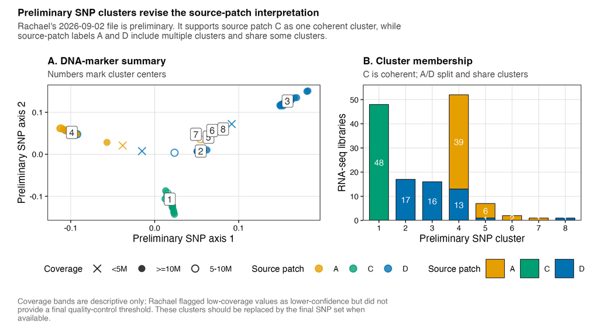

Preliminary DNA-marker groups, called clusters, change how we should talk about A, C, and D. These genetic groups are preliminary and should not be treated as final genetic identity. Here, a genetic individual means one confirmed clone. The file uses single-nucleotide polymorphisms (SNPs), which are single DNA-letter differences, from RNA sequencing (RNA-seq) libraries, meaning tissue samples prepared for sequencing. (a) Points place each library according to two ways of summarizing DNA-marker differences, colored by source patch. Cluster numbers mark the center of each group of genetically similar samples. Point shape shows coverage, a measure of how much sequence data supported that sample. (b) Bars show how many libraries fall in each preliminary SNP cluster, split by source patch. Source patch C is 48/48 in cluster 1. Source patches A and D split across several clusters, including shared clusters 4 and 5.

Source patch C forms one preliminary genetic cluster, but this does not yet confirm that all its fragments belong to one genetic individual. We assigned treatments by source patch before the genetic results were available. Some genetic clusters consequently have few samples in particular combinations of temperature, wound state, and day.

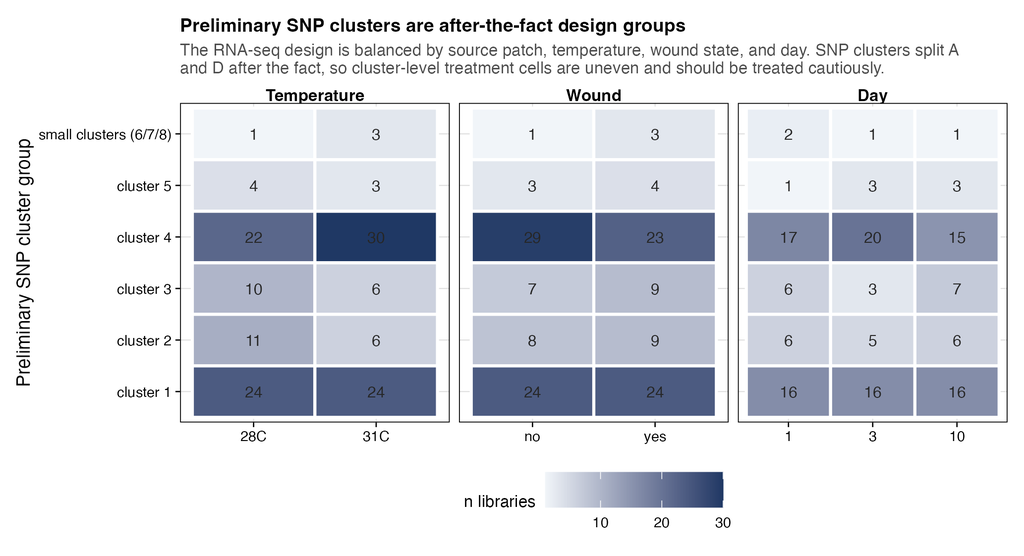

Preliminary DNA-marker groups, called clusters, were found after the experiment; they were not treatment groups. Tiles show how many RNA sequencing (RNA-seq) libraries, meaning tissue samples prepared for sequencing, fall in each preliminary single-nucleotide polymorphism (SNP) cluster by temperature, wound state, and sampling day. SNPs are single DNA-letter differences, and clusters are groups of genetically similar samples. The original design was balanced by source patch. The SNP clusters split A and D unevenly after the fact, so comparisons by cluster remain exploratory until the genetic assignments are finalized.

**Which responses can we link to DNA markers?** The current 144 sequenced fragments were sampled on Days 1, 3, and 10. Symbiont density is the only response measured on those same fragments that we can directly link to these markers.

The 48 fragments sampled on Day 15 have the broader response record: photosynthesis score and color through Day 14, growth and symbiont density at Day 15, and regrowth through Day 15. We do not yet have DNA-marker results for those fragments.

Genotyping the Day 15 fragments would let us ask whether genetic identity helps explain these responses and their changes under heat. That could be done without new gene-expression measurements. Additional RNA sequencing would address a separate question: which genes were active at the final sampling day.

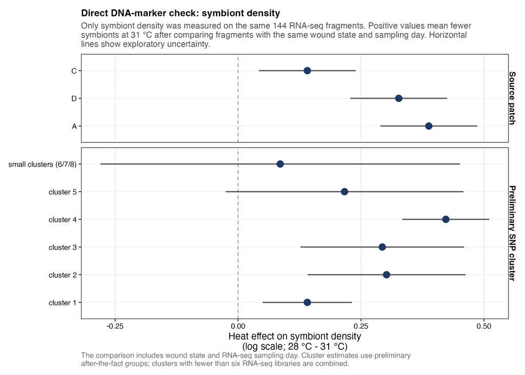

The preliminary symbiont comparison agrees with the source-patch result: fragments from C, which fall in cluster 1, lost fewer symbionts under heat. Because this uses the same response data, it is a different grouping of the evidence, not an independent replication.

**How the Hauru colonies might connect.** A preliminary survey of Hauru colonies by Trinity Conn and Ross Cunning provides a possible link to short-term heat responses. It lists colony locations, genetic groups, the most common symbionts, and responses to a short heat test.

Their heat-response measure is **ED50**: the temperature at which the photosynthesis-efficiency score falls halfway during that test. It describes a short exposure, not how long a coral can tolerate weeks of heat.

Source patch C is **10.5 m from Apul-115**, whose ED50 is 36.380 °C. A and D are closest to Apul-111. Nearby colonies can be genetically identical across field patches, so distance alone cannot identify a match.

Trinity’s table places Apul-115 in clonal group 2, a group of colonies identified as genetically identical, and labels its dominant symbiont “A.” That symbiont label is unrelated to our source patch A. These details may help guide a comparison of our DNA markers with the Hauru whole-genome data.

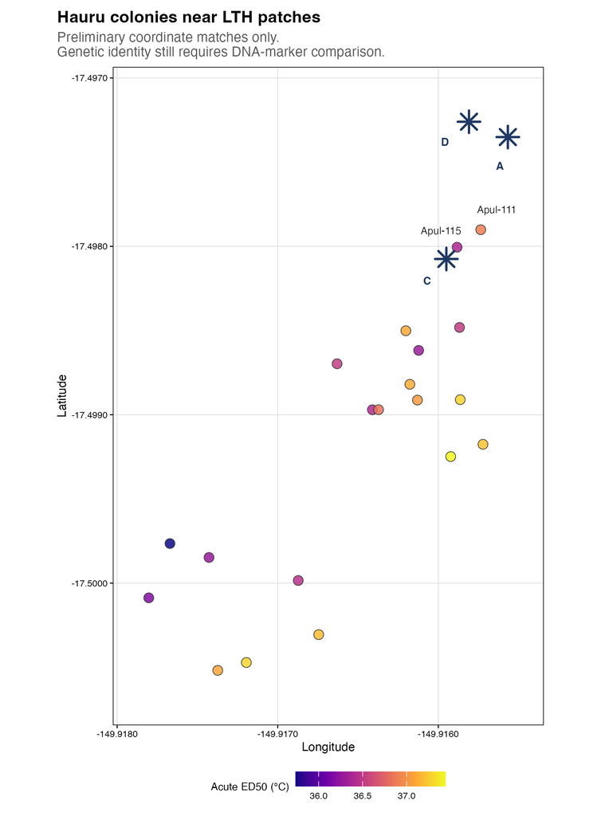

Source patch C lies near Apul-115, but a genetic match is unconfirmed. Stars show the LTH source patches A, C, and D. Circles show Hauru colonies from Trinity Conn’s 10 Aug 2026 table. Circle color shows acute heat limit, called ED50. ED50 is the temperature where the photosynthesis-efficiency score drops halfway during a short heat assay. Source patch C is closest to Apul-115, 10.5 m away, but genetically identical colonies can span field patches. Exact identity requires comparing DNA markers from our RNA sequencing (RNA-seq) data with Trinity/Ross whole-genome data.

Apul-115 and Apul-111 are candidates for genetic comparison. Their ED50 values cannot yet be assigned to source patches A, C, or D.

### 6. Weeks of heat affected corals below their short-test heat limit

Our 31 °C treatment was **4.4 °C below** the mean short-test ED50 of 35.4 °C reported by Cunning et al. (2024). ED50 is the temperature at which the photosynthesis-efficiency score falls halfway during a short heat test.

That comparison puts the treatment in context. It does not make 35.4 °C a safe limit for a longer exposure or establish the limit of our particular fragments.

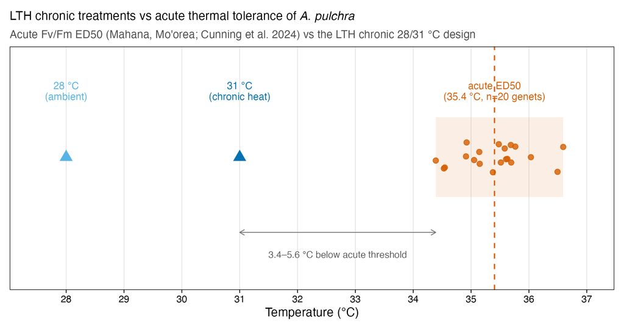

The 31 °C treatment was below temperatures that caused a half-drop in photosynthesis efficiency in a short heat test. The x-axis is temperature. Triangles mark the long-term heat (LTH) treatments: light blue = 28 °C and dark blue = 31 °C. Orange points show acute heat-limit values from Cunning et al. 2024. The specific metric is the half-drop temperature (ED50) for Fv/Fm, the same photosynthesis-efficiency score used above. ED50 is the temperature where that score drops halfway. The orange band spans the ED50 range, and the dashed orange line marks the mean ED50, 35.4 °C. The gray arrow shows that 31 °C is 3.4-5.6 °C below that short-test range. These values are not safe limits for weeks of exposure.

Even at 31 °C, sustained exposure reduced coral condition and the percentage completing regrowth by Day 15.

## Take-homes

- **The temperature difference held.** All eight tanks have a complete logger record through Day 15, with a mean difference of 3.09 °C.
- **Heat reduced coral condition.** Heated fragments had lower photosynthesis scores, paler color, fewer symbionts, and lower average skeletal growth. The growth difference is less certain. Tip clipping added little to these changes.
- **Wound covering and later regrowth differed.** Wounds re-covered quickly at both temperatures. Only 4/12 heated wounded fragments budded new corallites by Day 15, compared with 12/12 at 28 °C. We do not know whether the others would have budded later.
- **Source patch C was less affected by heat.** The clearest differences were in photosynthesis score, color, and symbiont density. Its genetic identity remains preliminary.
- **Trade-offs remain unresolved.** C grew less at 28 °C but lost less growth under heat. Within heated wounded fragments, we found no clear evidence that regrowth came at a cost to growth. The small sample cannot rule out a cost.
- **More genetic data could connect the results.** Current DNA markers link directly only to symbiont density. Genotyping the Day 15 fragments could connect genetic identity to the broader response record. Matching our fragments to the Hauru colonies would also allow a direct comparison with their short-test heat responses.

## Open questions

- **Does genetic identity explain differences in heat response?** Final genetic assignments and genotyping of the 48 Day 15 fragments would connect identity to photosynthesis, color, growth, symbiont density, and regrowth.
- **Which gene responses accompany slower regrowth?** Gene-expression comparisons can test whether heat changes activity associated with rebuilding the wounded tip.
- **Do short-test heat responses predict performance during sustained heat?** Confirmed DNA matches to the Hauru colonies would allow this comparison.
- **How certain are the repair-timing estimates?** The two flagged scoring records need review, and timing uncertainty needs to account for fragments sharing a tank.

Coral photos and experimental design: LTH field team (M. Brzezinski). Preliminary genetic analyses: Rachael Bay and collaborators. Hauru colony data: Trinity Conn and Ross Cunning.